# Understanding Bikes Trips in California's Bay Area

## by Mohamed M. Saad

## Investigation Overview

In this study, we check the main factors that affects bikes trips. Studying these factors helps in understanding the user needs and distribute bikes over the stations in an efficient way.

Bay Wheels is a regional public bicycle sharing system in California's San Francisco Bay Area. It is operated by Motivate in a partnership with the Metropolitan Transportation Commission and the Bay Area Air Quality Management District.

As bikes move between stations, a good understanding of the trips flow will allow to provide better service and allocate (or re-distribute) bikes to stations accoridng to the user needs

You can download the data from the following link https://s3.amazonaws.com/baywheels-data/2017-fordgobike-tripdata.csv.zip

Bay Wheels's trip data for public use under Bay Wheels License Agreement, and I will use it to visualize some of the relationship between its fields.

## Dataset Overview

The data used for this investigation is the collected information for the year 2017. It consists of arround half million trips information. Each trip is anonymized and includes:

- Trip Duration (seconds)
- Start Time and Date
- End Time and Date
- Start Station ID
- Start Station Name
- Start Station Latitude
- Start Station Longitude
- End Station ID
- End Station Name
- End Station Latitude
- End Station Longitude
- Bike ID
- User Type (Subscriber or Customer – “Subscriber” = Member or “Customer” = Casual)

## Trip Duration

The distribution of duration on all the dataset is unimodal with right skewed long tail. Values ranges from few minutes to around one day.

Only 6% of data represents trips that is longer than 45 minutes, so we will plot the distribution of this 'Long Trips' in another plots that the other 94% of data for trips that are less than 45 minutes.

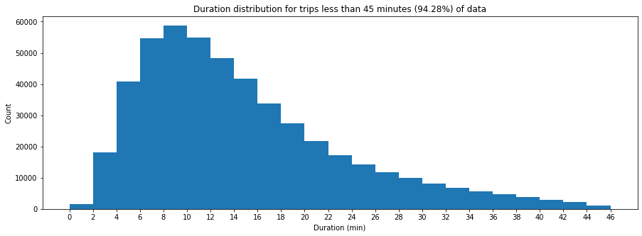

```python
plt.figure(figsize = [15, 5])
step = 2
duration_bins = np.arange(0, short_trip_max_min + step, step)
plt.hist(data = df[df['short_trip']], x = 'duration_min', bins = duration_bins);
plt.xticks(duration_bins);
plt.xlabel("Duration (min)")
plt.ylabel("Count")
plt.title("Duration distribution for trips less than {:2} minutes ({:2.2f}%) of data".format(short_trip_max_min, normal_trips_count));
plt.show()
```

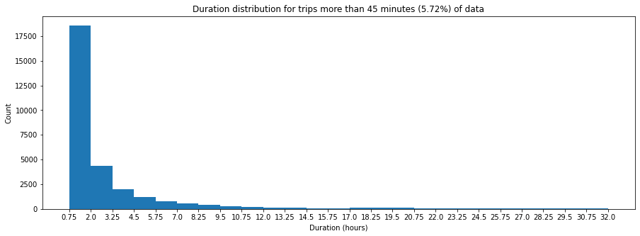

```python
plt.figure(figsize = [15, 5])
step = 75 # 1.25 hour as a step
duration_bins = np.arange(short_trip_max_min, df['duration_min'].max() + step, step)
duration_ticks = np.arange(short_trip_max_min/60, (df['duration_min'].max() + step)/60, step/60)

plt.hist(data = df[(df['short_trip'] == False)], x = 'duration_min', bins = duration_bins);
plt.xticks(duration_bins, duration_ticks);
plt.xlabel("Duration (hours)")
plt.ylabel("Count")
plt.title("Duration distribution for trips more than {:2} minutes ({:2.2f}%) of data".format(short_trip_max_min, (100 - normal_trips_count)));
plt.show()
```

## Trip Source/Destination Distance

Using the trip start and end stations, we can calcualte the euclidien distance between them and set this as a lower bound estimate to the trip distance as it is the shortest path between points.

The following code will calcualte euclidien distance, It is available online and cited at the references section at the end of the report.

We will need to drop two types of points

- Start and end stations are the same as this will give us wrong zero distance as the user returned the bick to the same station he took (total 18134 points)
- Outliers that trip distance more than 10km (only 67 points)

Plotting the distribution shows a right skewed bi-modal distribution with 1.4 Km median and 1.6 Km mean. It worth noting that the distance between pick-up and drop-off bick is less than 10KM for over 99% of data.

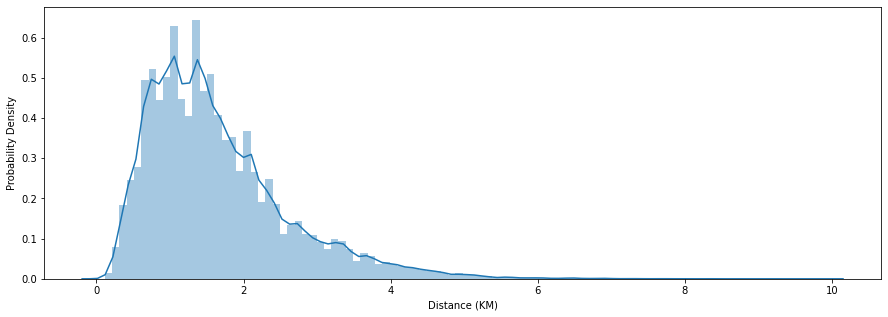

```python
from math import radians, cos, sin, asin, sqrt
def haversine(lon1, lat1, lon2, lat2):
    """
    Calculate the great circle distance between two points
    on the earth (specified in decimal degrees)
    """
    # convert decimal degrees to radians
    lon1, lat1, lon2, lat2 = map(radians, [lon1, lat1, lon2, lat2])
    # haversine formula
    dlon = lon2 - lon1
    dlat = lat2 - lat1
    a = sin(dlat/2)**2 + cos(lat1) * cos(lat2) * sin(dlon/2)**2
    c = 2 * asin(sqrt(a))
    # Radius of earth in kilometers is 6371
    km = 6371* c
    return km

df['distance'] =  df.apply(lambda row: haversine(
            row['start_station_longitude'], row['start_station_latitude'],
            row['end_station_longitude'], row['end_station_latitude']), axis=1)

# remove points where start & end points are the same
df_distance = df[df['start_station_id']!=df['end_station_id']]
# remove outliers
df_distance = df_distance[df_distance['distance'] <= 10]

plt.figure(figsize = [15, 5])
sb.distplot(df_distance['distance'], norm_hist=True, bins=100)
plt.xlabel("Distance (KM)")
plt.ylabel("Probability Density")
plt.show()
```

## Trip Time

Another important aspect is the start and end time for trips because it shows what is the peak times for taking or returning the bikes. Let us check the distributions of time grouped by the following granularities:

#### Hour of the day

We see a bimodal with two peaks at 8 AM & 5 PM for both the trip start/end. This is the standard start/end for business days, so seems that most of users use bikes to go to (or return from) work.

#### Day of the Week

The distribution of trips over the day of the week reveals that Weekends shows the lowest trips count, but the longest trips. This indicates that most of the users uses bikes as a means for transportation not for fun.

#### Months

A breakdown with the trips counts per month is plotted at the left, and a finer plot on the level of weeks to the right. The highest number of trips recorded was at October while is more than double the trips at July (the lowest month).

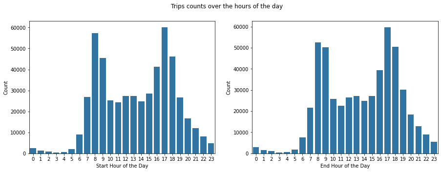

```python
plt.figure(figsize = [15, 5])
plt.suptitle('Trips counts over the hours of the day')
plt.subplot(1, 2, 1)
sb.countplot(data = df, x = 'start_hour', color = sb.color_palette()[0]);
plt.xlabel("Start Hour of the Day")
plt.ylabel("Count")
plt.subplot(1, 2, 2)
sb.countplot(data = df, x = 'end_hour', color = sb.color_palette()[0]);
plt.xlabel("End Hour of the Day");
plt.ylabel("Count")
plt.show()
```

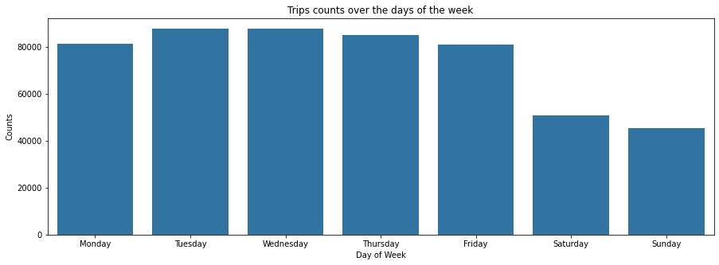

```python
days = ['Monday', 'Tuesday', 'Wednesday', 'Thursday', 'Friday', 'Saturday', 'Sunday']
plt.figure(figsize = [15, 5])
sb.countplot(data = df, x = 'day_of_week', color = sb.color_palette()[0]);
plt.xticks(np.arange(0,7,1), days);
plt.title('Trips counts over the days of the week');
plt.xlabel("Day of Week")
plt.ylabel("Counts")
plt.show()
```

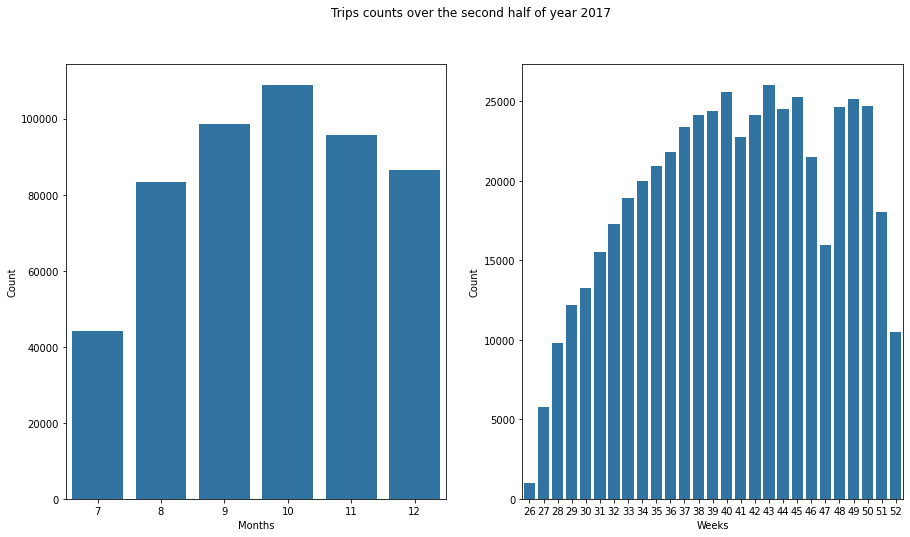

```python
# Data for July seems too few, so skip it from the figure
plt.figure(figsize = [15, 8])
plt.suptitle('Trips counts over the second half of year 2017');

plt.subplot(1, 2, 1)
sb.countplot(data = df[df['month_of_year']>6], x = 'month_of_year', color = sb.color_palette()[0]);
plt.xlabel("Months")
plt.ylabel("Count")

plt.subplot(1, 2, 2)
sb.countplot(data = df[df['month_of_year']>6], x = 'week_of_year', color = sb.color_palette()[0]);
plt.xlabel("Weeks")
plt.ylabel("Count")
plt.show()
```

## Long Trip vs Short Trip

Recall that we split the trips into: short trips and long trips, where short trip is the one less than 45 minutes. Short trips represents the majority of the data (~ 94%) and usually represents in-town trips, while long trips represents cross-town (high way) trips.

Let us see the charactersitcs for Short and Long trip versus

- The types of users: **Supscribers and Customers**, and
- The day of the week **Weekday vs Weekend**.

As we see from the figures below, for short trips Subscripers on average have shorter trips than Customers. On the other hand, for long trips both Subscripers and Customers have almost the same mean and median, but the number of Customers for are much larger than Subscripers. It worth noting that most of Bay Wheels users are Supscribers (79%)

For short trips, sers have longer trips during weekends than weekdays, while for long trips there is no big distinguishing between the different days of the week.

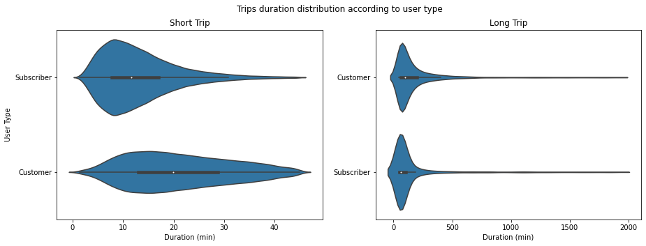

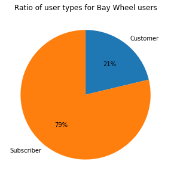

```python
plt.figure(figsize = [15, 5])
plt.suptitle('Trips duration distribution according to user type')

plt.subplot(1, 2, 1)
sb.violinplot(data = df[df['short_trip']], y = 'user_type', x = 'duration_min', color = sb.color_palette()[0])
plt.xlabel("Duration (min)")
plt.ylabel("User Type")
plt.title("Short Trip")

plt.subplot(1, 2, 2)
sb.violinplot(data = df[df['short_trip'] == False], y = 'user_type', x = 'duration_min', color = sb.color_palette()[0])
plt.xlabel("Duration (min)")
plt.ylabel("")
plt.title("Long Trip")
plt.show()
plt.figure(figsize = [5, 5])
df_user_types = df.groupby('user_type').size()
plt.pie(df_user_types, labels = df_user_types.index, startangle = 90, counterclock = False,
        autopct=lambda val:"{:2.0f}%".format(val));
plt.title("Ratio of user types for Bay Wheel users");


plt.show()
```

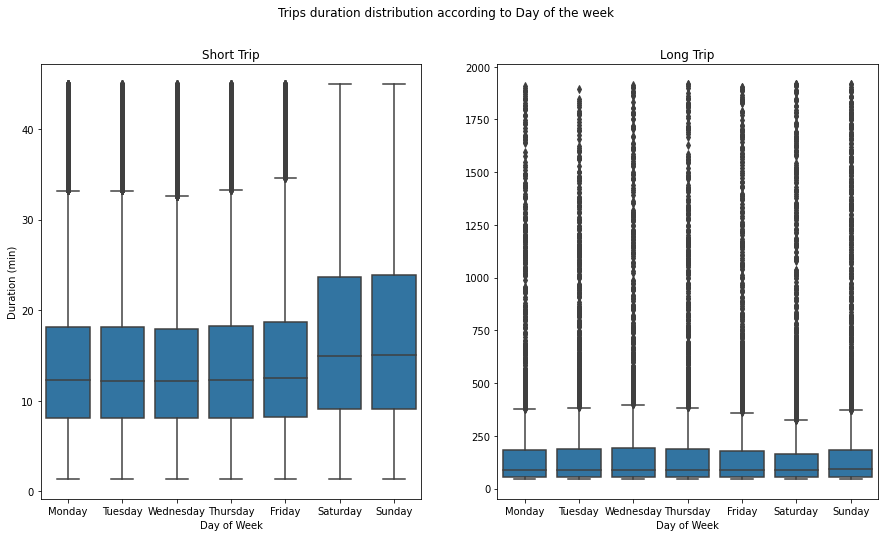

```python
plt.figure(figsize = [15, 8])
plt.suptitle('Trips duration distribution according to Day of the week')

plt.subplot(1, 2, 1)
sb.boxplot(data = df[df['short_trip']], x = 'day_of_week', y = 'duration_min', color = sb.color_palette()[0])
plt.xticks(np.arange(0,7,1), days);
plt.xlabel("Day of Week")
plt.ylabel("Duration (min)")
plt.title('Short Trip');

plt.subplot(1, 2, 2)
sb.boxplot(data = df[df['short_trip'] == False], x = 'day_of_week', y = 'duration_min', color = sb.color_palette()[0])
plt.xticks(np.arange(0,7,1), days);
plt.xlabel("Day of Week")
plt.ylabel("")
plt.title('Long Trip');

plt.show()
```

## Stations Distribution

The geographical locations determined by two variables: Latitude & Longitude. Ploting a scatter plot between them shows the geographic distribution of stations.

From the first plot, we will notice the stations are clustetred into three main groups: San Francisco, Oakland and San Jose. The rest of plots shows the distribution of stations on each of these three clusters.

We notice that the distribution of the stations is on the main roads in all the cities.

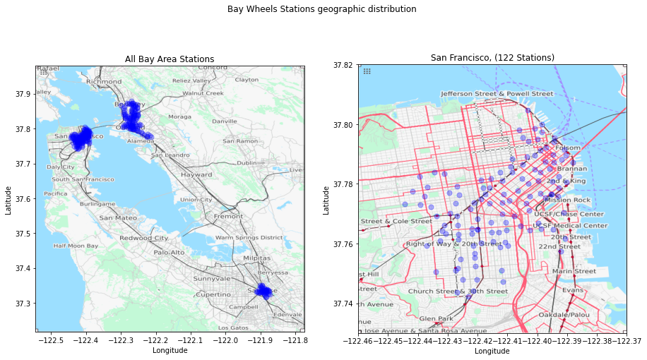

```python
# Plot given geo data on the given image
def plot_map(box, img, title, i):
    ruh_m = plt.imread(img)
    ax = plt.subplot(1, 2, i)
    ax.scatter(df_stations.start_station_longitude, df_stations.start_station_latitude, zorder=1,
               alpha= 0.3, c='b', s=50)
    ax.set_title(title)
    ax.set_xlim(box[0],box[1])
    ax.set_ylim(box[2],box[3])
    ax.set_xlabel("Longitude")
    ax.set_ylabel("Latitude")
    ax.imshow(ruh_m, zorder=0, extent = box)

# Filter given data on the box boundry
def filter_location(all_df, box, action):
    filtered = all_df[(all_df[action + "_station_longitude"] > box[0]) &
                  (all_df[action + "_station_longitude"] < box[1]) &
                  (all_df[action + "_station_latitude"] > box[2]) &
                  (all_df[action + "_station_latitude"] < box[3])
                 ]
    return filtered

# Set a box arround all the stations
long_margin = 0.1
lat_margin = 0.1
bay_box = (  df_stations.start_station_longitude.min()-long_margin,
             df_stations.start_station_longitude.max()+long_margin,
             df_stations.start_station_latitude.min()-lat_margin,
             df_stations.start_station_latitude.max()+lat_margin
           )
# Set a boundy box for the three cities
san_box = (-122.46, -122.37, 37.73, 37.82)
oak_box = (-122.31, -122.20, 37.76, 37.89)
jose_box = (-121.915,-121.87, 37.315, 37.355)

# Filter stations per each city
san_stations_start = filter_location(df_stations, san_box, "start")
oak_stations_start = filter_location(df_stations, oak_box, "start")
jose_stations_start = filter_location(df_stations, jose_box, "start")

# Plot
plt.figure(figsize = [15, 8])
plt.suptitle('Bay Wheels Stations geographic distribution')

plt.ylim()
plot_map(bay_box, 'res/bay.png', 'All Bay Area Stations', 1)
plot_map(san_box, 'res/san.png', 'San Francisco, ({:2d} Stations)'.format(san_stations_start.shape[0]), 2)
plt.show()
```

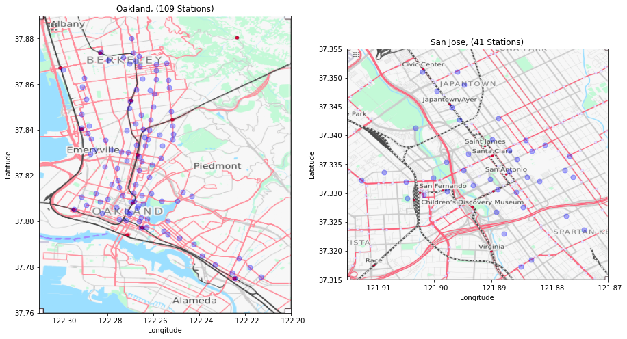

```python
plt.figure(figsize = [15, 8])
plot_map(oak_box, 'res/oak.png', 'Oakland, ({:2d} Stations)'.format(oak_stations_start.shape[0]), 1)
plot_map(jose_box, 'res/jose.png', 'San Jose, ({:2d} Stations)'.format(jose_stations_start.shape[0]), 2)
plt.show()
```

## Station Geographic vs Bick Pickup & Drop-off

In the previous section we show the distribution of the stations over the bay area. Here we will plot the relationship between stations used to pick-up the bick and the ons used for the drop-off.

For each station, will group all trips pick-ups (start-station), and drop-off (end-station). Then plot a scatter plot on the difference with diverging paletter to understand the bikes flow at a given day.

Here I selected a day in October which is a peak case for the dataset. The first plot shows the dynamic movement of bikes between stations during this day. As we see, most of the stations has a balance (between +/- 10 bikes), and very few stations have less than 20 bikes shortage at that day.

Plotting the same figure for all the data almost have the same distribution.

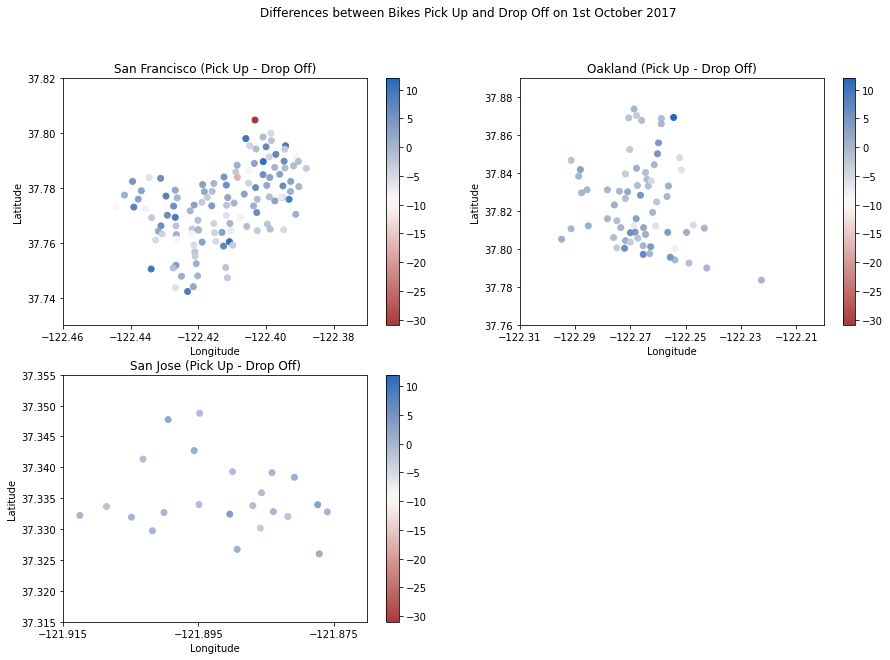

```python
def plot_diff(df_diff, title, box, i):
    plt.subplot(2, 2, i)
    plt.scatter(data = df_diff, x = 'start_station_longitude', y = 'start_station_latitude', c = 'diff',
                cmap = 'vlag_r')
    plt.xlim(box[0], box[1])
    plt.ylim(box[2], box[3])
    x_ticks = np.arange(box[0], box[1], 0.02)
    plt.ylabel("Latitude")
    plt.xlabel("Longitude")
    plt.xticks(x_ticks)
    plt.title(title)
    plt.colorbar()

def plot_bike_traffic(traffic_df):
    pick_up = pd.DataFrame(traffic_df.groupby(['start_station_id', 'start_station_longitude', 'start_station_latitude']).size(), columns = ['pick'])
    pick_up.reset_index(inplace=True)
    drop_off = pd.DataFrame(traffic_df.groupby(['end_station_id', 'end_station_longitude', 'end_station_latitude']).size(), columns = ['drop'])
    drop_off.reset_index(inplace=True)

    df_diff = pd.merge(pick_up, drop_off,
                        left_on = ['start_station_id', 'start_station_longitude', 'start_station_latitude'],
                        right_on = ['end_station_id', 'end_station_longitude', 'end_station_latitude'],
                        how = 'right')
    df_diff['diff'] = df_diff['pick'] - df_diff['drop']

    plt.figure(figsize = [15, 10])
    plot_diff(df_diff, "San Francisco (Pick Up - Drop Off)", san_box, 1)
    plot_diff(df_diff, "Oakland (Pick Up - Drop Off)", oak_box, 2)
    plot_diff(df_diff, "San Jose (Pick Up - Drop Off)", jose_box, 3)

first_october_df = df[(df['start_time'] > '2017-10-01 00:00:00') & (df['start_time'] < '2017-10-01 23:59:59')]
plot_bike_traffic(first_october_df)
plt.suptitle("Differences between Bikes Pick Up and Drop Off on 1st October 2017");

plt.show()
```

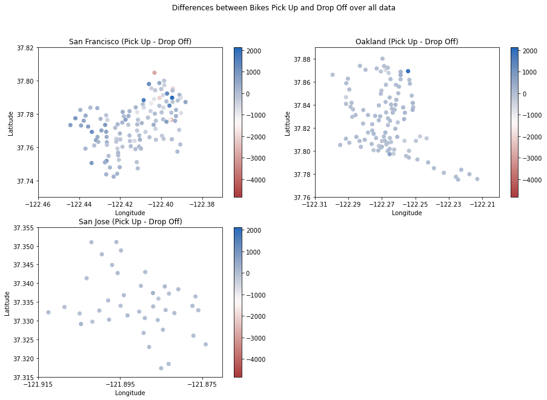

```python
plot_bike_traffic(df)
plt.suptitle("Differences between Bikes Pick Up and Drop Off over all data");
plt.show()
```

## Distinct Bikes vs Station

As each bike has a different identifier, we can show the relationship between station location and how many distinct bikes passed by this station.

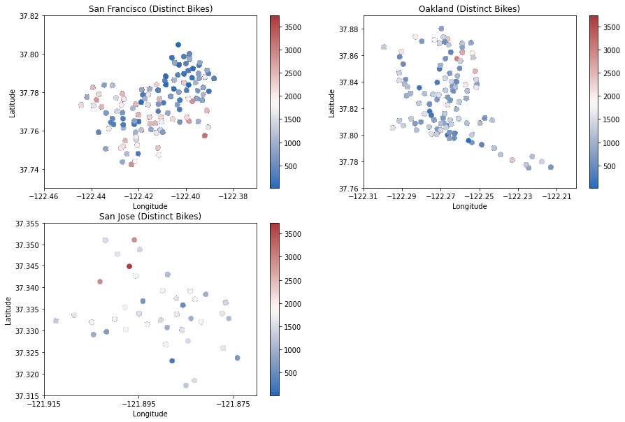

```python
def plot_bikes(df_bike, title, box, i):
    plt.subplot(2, 2, i)
    plt.scatter(data = df_bike, x = 'longitude', y = 'latitude', c = 'bike_id',
                cmap = 'vlag')
    plt.xlim(box[0], box[1])
    plt.ylim(box[2], box[3])
    x_ticks = np.arange(box[0], box[1], 0.02)
    plt.ylabel("Latitude")
    plt.xlabel("Longitude")
    plt.xticks(x_ticks)
    plt.title(title)
    plt.colorbar()

# Collect distinct bikes at either start or end of trip
df_bike_start = df[['bike_id', 'start_station_longitude', 'start_station_latitude']].rename(columns={'start_station_longitude': 'longitude', 'start_station_latitude': 'latitude' }, inplace=False)
df_bike_end = df[['bike_id', 'end_station_longitude', 'end_station_latitude']].rename(columns={'end_station_longitude': 'longitude', 'end_station_latitude': 'latitude' }, inplace=False)
# Concate data and drop duplicates
df_bike = pd.concat([df_bike_start, df_bike_end])
df_bike.drop_duplicates(inplace=True)

plt.figure(figsize = [15, 10])
plot_bikes(df_bike, "San Francisco (Distinct Bikes)", san_box, 1)
plot_bikes(df_bike, "Oakland (Distinct Bikes)", oak_box, 2)
plot_bikes(df_bike, "San Jose (Distinct Bikes)", jose_box, 3)
plt.show()
```

## Summary of Observations

The study of Bar Wheels data reveals the following facts about the trips characterstics

# Thanks

### References

- Lyft https://www.lyft.com/bikes/bay-wheels/system-data
- Wikipedia https://en.wikipedia.org/wiki/Bay_Wheels
- Open Street Maps https://www.openstreetmap.org/
- Estimate the distance between two points (latitude, longitude) https://stackoverflow.com/questions/15736995/how-can-i-quickly-estimate-the-distance-between-two-latitude-longitude-points
- Plotting Geigraohic Data https://towardsdatascience.com/easy-steps-to-plot-geographic-data-on-a-map-python-11217859a2db